# The Association of GDP and Income Around the World

Dan Freeman

April 10, 2017

# Introduction

# Packages Needed

```r
#install.packages("plyr")
#install.packages("ggplot2")
library(plyr)
library(ggplot2)
```

# REMEMBER TO SET YOUR WORKING DIRECTORY!

```r
setwd("C:/Users/Dan Freeman/Documents/Southern Methodist University - MS in Data Science/Spring 2017 Courses/MSDS 6306 Doing Data Science/Case Study 1")
```

# Education and GDP Data Imports

```r
Education <- read.csv("https://d396qusza40orc.cloudfront.net/getdata%2Fdata%2FEDSTATS_Country.csv", header=TRUE, sep=",")
GDP <- read.csv("https://d396qusza40orc.cloudfront.net/getdata%2Fdata%2FGDP.csv", skip=3, header=TRUE, sep=",")
```

# GDP Data Cleaning

```r
GDP_Clean <- (GDP$X.1 <- GDP$X.2 <- GDP$X.3 <- GDP$X.4 <- GDP$X.5 <- GDP$X.6 <-NULL) #Delete extraneous variables.
GDP <- rename(GDP, c(X="CountryCode", US.dollars.="GDP")) #Rename variables to more meaningful names.
GDP <- subset(GDP, CountryCode!="") #Delete cases whose country code is missing.

GDP$GDP <- as.numeric(gsub(",", "", as.character(GDP$GDP))) #Convert GDP to numeric variable.
GDP$Ranking <- as.numeric(gsub(",", "", as.character(GDP$Ranking))) #Convert Ranking to numeric variable.
```

# Education and GDP Data Merging by Country Code

```r
Education_GDP <- merge(Education, GDP, by="CountryCode")
```

224 of the Country Codes are found in both the Education and GDP data sets.

# Merged Data Set Sorted in Ascending Order by GDP

```r
Education_GDP <- Education_GDP[order(Education_GDP$GDP),]
```

St. Kitts and Nevis is the 13th country in the Education_GDP data set sorted ascending by GDP.

```r
summary(subset(Education_GDP, Education_GDP$Income.Group == "High income: nonOECD")$Ranking)
```

```
##    Min. 1st Qu.  Median    Mean 3rd Qu.    Max.    NA's
##   19.00   58.50   94.00   91.91  125.00  161.00      14
```

The average GDP ranking for High income:nonOECD countries is 91.91.

```r
summary(subset(Education_GDP, Education_GDP$Income.Group == "High income: OECD")$Ranking)
```

```
##    Min. 1st Qu.  Median    Mean 3rd Qu.    Max.
##    1.00   12.25   24.50   32.97   45.75  122.00
```

The average GDP ranking for High income:OECD countries is 32.97.

# Density Plot of GDP by Income Group

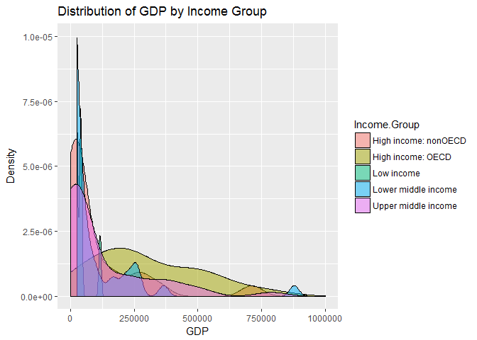

From the plot above, countries in the Lower Middle Income group are more likely to have a GDP of less than $100 billion than other income groups. High Income: OECD countries are generally the most likely to have a GDP greater than $125 billion. However, Lower Middle Income countries are more likely to have a GDP between approximately $850 billion and $900 billion than other income groups. Also, High Income:nonOECD countries are more likely to have a GDP of less than $100 billion than Upper middle income countries.